# richards_finalproject (1)

### Madeline Richards

#### 1. Data gathering

I used BeautifulSoup to scrape tennis data from Wikipedia and used a live twitter API to get tweet data from a tennis player's account.

#### 2. Data cleaning

I used regex with capture groups in the wiki data, changed the 'result' column to an integer than can be counted, resampled time data for twitter data, and more.

#### 3. Data manipulation

Created a SQL database tying the data together and created an ER diagram. Merges and joins in pandas are found throughout the project. Aggregations by sum, mean, count, pval and correlation, etc are used to answer questions about the data.

#### 4. Data reporting

Created many graphs using matplotlib that demonstrate findings in the data and comparisons between tennis players. Rolling window is used for twitter data favorite counts.

# 330 Final Project: William Sister's Tennis and Twitter Data

Women’s tennis is fast-pasted, entertaining, and full of interesting data. I propose that our media group should work with women’s tennis data to start data-driven marketing in sports reporting. In particular, I will be looking at the most decorated women's tennis sisters: Venus and Serena Williams.

[figure not shown]

Venus (39) and Serena (38) have a long history of dominance on the court both as doubles partners and individual competitors. As someone not usually interested in watching sports, I became invested in watching Serena's journey to attempt to win all four Grand Slam's in 2015. (She came short by one.) I think there is an opportunity to make connections like this using the data of great players to showcase just how amazing their accomplishments are.

## Data I hope to use:

Twitter Data

- Serena and Venus's twitter retweets and favorites through the years

Tennis Grand Slam Data

- Number of Grand Slam wins and losses for each player
- Grand Slam wins by year for each player
- Grand Slam years by tournament (location) for each player

Tying the Data Together

- Do the years the players win more Grand Slams correlate with more twitter retweets and favorites?

## Code

### Gathering and Cleaning Tennis Data:

The data tennis is scraped from Wikipedia using Beautifulsoup. The data was originally very messy, one reason being the result (win vs loss) did not have an element class in the HTML, so it had to be called by its background color. The rest of the data was one big string so I used regex capture groups and then concatenated it with the result data frame.

The function takes in a URL, so I first passed Serena, then Venus's page to it. The first table that is printed out is what it looked like before the capture groups and clean-up, and the second table is the new, clean pandas data frame.

BEFORE RUN KERNAL:

- pip install twitter
- pip install tweepy
- sudo service postgresql start

```python
import requests
from bs4 import BeautifulSoup
import pandas as pd
import re
import numpy as np
import matplotlib.pyplot as plt
import pandas as pd
import seaborn as sns
```

```python
def get_wiki_data(url):
    page = requests.get(url)


    soup = BeautifulSoup(page.content, 'html.parser')

    table = soup.find_all('table', class_="sortable wikitable")[0]

    rows = table.findAll('tr')


    all_data = []
    all_title_data = []


    for row in rows:
        links = row.findAll('a')
        all_data.append(links)


    for row_links in all_data:
        title_data = []
        if len(row_links) > 0:
            for link in row_links:
                title = link.get('title')
                title_data.append(title)
        all_title_data.append(title_data)


    etc = []

    for lst in all_title_data:
        if len(lst) > 0:
            etc.append(lst[0])


    dx = pd.DataFrame()
    dx['Data'] = etc

    wl = table.findAll(('td'), {'style':re.compile("background:#98fb98|background:#ffa07a")})

    wl_list = []

    for row in wl:
        row = row.renderContents()
        encoding = 'utf-8'
        row = row.decode(encoding)
        wl_list.append(row)

    df = pd.DataFrame()
    df['result'] = wl_list

    m = pd.concat([df, dx], join="outer", axis = 1)
    print(m)

    m['Data']= m['Data'].str.replace(r' – Women\'s Singles','')
    m['Data']= m['Data'].str.replace(r' \(tennis\)','')
    m[['year', 'tournament']] = m["Data"].str.extract('(?P<year>\d{4}) (?P<tornament>.+)')
    m = m[["result", "year", "tournament"]]

    return(m)
```

### Serena's Data:

```python
serena_wiki = get_wiki_data("https://en.wikipedia.org/wiki/Serena_Williams")
serena_wiki
```

```
   result                                            Data
0     Win                  1999 US Open – Women's Singles
1    Loss                  2001 US Open – Women's Singles
2     Win              2002 French Open – Women's Singles
3     Win  2002 Wimbledon Championships – Women's Singles
4     Win                  2002 US Open – Women's Singles
5     Win          2003 Australian Open – Women's Singles
6     Win  2003 Wimbledon Championships – Women's Singles
7    Loss  2004 Wimbledon Championships – Women's Singles
8     Win          2005 Australian Open – Women's Singles
9     Win          2007 Australian Open – Women's Singles
10   Loss  2008 Wimbledon Championships – Women's Singles
11    Win                  2008 US Open – Women's Singles
12    Win          2009 Australian Open – Women's Singles
13    Win  2009 Wimbledon Championships – Women's Singles
```

[output cut: 19 more lines]

|  | result | year | tournament |
| --- | --- | --- | --- |
| 0 | Win | 1999 | US Open |
| 1 | Loss | 2001 | US Open |
| 2 | Win | 2002 | French Open |
| 3 | Win | 2002 | Wimbledon Championships |
| 4 | Win | 2002 | US Open |
| 5 | Win | 2003 | Australian Open |
| 6 | Win | 2003 | Wimbledon Championships |
| 7 | Loss | 2004 | Wimbledon Championships |
| 8 | Win | 2005 | Australian Open |
| 9 | Win | 2007 | Australian Open |
| 10 | Loss | 2008 | Wimbledon Championships |
| 11 | Win | 2008 | US Open |
| 12 | Win | 2009 | Australian Open |
| 13 | Win | 2009 | Wimbledon Championships |
| 14 | Win | 2010 | Australian Open |
| 15 | Win | 2010 | Wimbledon Championships |
| 16 | Loss | 2011 | US Open |
| 17 | Win | 2012 | Wimbledon Championships |
| 18 | Win | 2012 | US Open |
| 19 | Win | 2013 | French Open |
| 20 | Win | 2013 | US Open |
| 21 | Win | 2014 | US Open |
| 22 | Win | 2015 | Australian Open |
| 23 | Win | 2015 | French Open |
| 24 | Win | 2015 | Wimbledon Championships |
| 25 | Loss | 2016 | Australian Open |
| 26 | Loss | 2016 | French Open |
| 27 | Win | 2016 | Wimbledon Championships |
| 28 | Win | 2017 | Australian Open |
| 29 | Loss | 2018 | Wimbledon Championships |
| 30 | Loss | 2018 | US Open |
| 31 | Loss | 2019 | Wimbledon Championships |
| 32 | Loss | 2019 | US Open |

### Venus's Data:

```python
venus_wiki = get_wiki_data("https://en.wikipedia.org/wiki/Venus_Williams")
venus_wiki
```

```
   result                          Data
0    Loss         1997 US Open (tennis)
1     Win  2000 Wimbledon Championships
2     Win         2000 US Open (tennis)
3     Win  2001 Wimbledon Championships
4     Win         2001 US Open (tennis)
5    Loss              2002 French Open
6    Loss  2002 Wimbledon Championships
7    Loss         2002 US Open (tennis)
8    Loss          2003 Australian Open
9    Loss  2003 Wimbledon Championships
10    Win  2005 Wimbledon Championships
11    Win  2007 Wimbledon Championships
12    Win  2008 Wimbledon Championships
13   Loss  2009 Wimbledon Championships
14   Loss          2017 Australian Open
15   Loss  2017 Wimbledon Championships
```

|  | result | year | tournament |
| --- | --- | --- | --- |
| 0 | Loss | 1997 | US Open |
| 1 | Win | 2000 | Wimbledon Championships |
| 2 | Win | 2000 | US Open |
| 3 | Win | 2001 | Wimbledon Championships |
| 4 | Win | 2001 | US Open |
| 5 | Loss | 2002 | French Open |
| 6 | Loss | 2002 | Wimbledon Championships |
| 7 | Loss | 2002 | US Open |
| 8 | Loss | 2003 | Australian Open |
| 9 | Loss | 2003 | Wimbledon Championships |
| 10 | Win | 2005 | Wimbledon Championships |
| 11 | Win | 2007 | Wimbledon Championships |
| 12 | Win | 2008 | Wimbledon Championships |
| 13 | Loss | 2009 | Wimbledon Championships |
| 14 | Loss | 2017 | Australian Open |
| 15 | Loss | 2017 | Wimbledon Championships |

### Manipulating Tennis Data:

###### Here, I am getting the win and loss counts of Grand Slams.

```python
s_result_df = serena_wiki[['result','year']]
s_win_loss_count = s_result_df.groupby(['result']).count()
print("Serena's Win and Loss Count:")
s_win_loss_count
```

```
Serena's Win and Loss Count:
```

| result | year |
| --- | --- |
| Loss | 10 |
| Win | 23 |

```python
v_result_df = venus_wiki[['result','year']]
v_win_loss_count = v_result_df.groupby(['result']).count()
print("Venus's Win and Loss Count:")
v_win_loss_count
```

```
Venus's Win and Loss Count:
```

| result | year |
| --- | --- |
| Loss | 9 |
| Win | 7 |

###### From the pie charts, you see the breakdown of losses vs wins for both players. Serena won a higher percentage of tournaments she played in (23 out of 33) than Venus (7 out of 16).

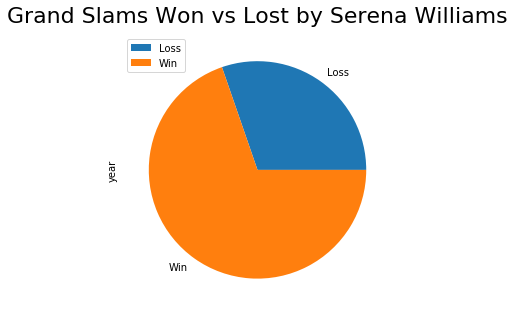

```python
plot = s_win_loss_count.plot.pie(y='year', figsize=(5, 5))
plt.title("Grand Slams Won vs Lost by Serena Williams", y=1.02, fontsize=22);
```

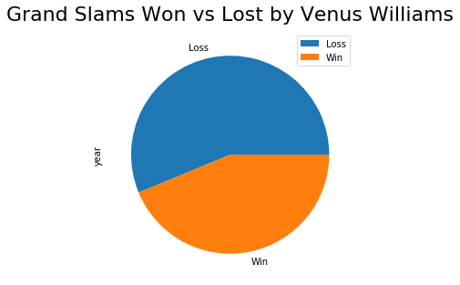

```python
plot = v_win_loss_count.plot.pie(y='year', figsize=(5, 5))
plt.title("Grand Slams Won vs Lost by Venus Williams", y=1.02, fontsize=22);
```

###### Now to get the win counts by year, the result column needs to only include the wins. I changed the win count column to the integer 1 to aggregate it a pivot table by sum.

```python
s_win_df = s_result_df.loc[s_result_df['result']=='Win']
s_win_df['win_count'] = 1
s_win_df = s_win_df[['year', 'win_count']]
s_win_df
```

|  | year | win_count |
| --- | --- | --- |
| 0 | 1999 | 1 |
| 2 | 2002 | 1 |
| 3 | 2002 | 1 |
| 4 | 2002 | 1 |
| 5 | 2003 | 1 |
| 6 | 2003 | 1 |
| 8 | 2005 | 1 |
| 9 | 2007 | 1 |
| 11 | 2008 | 1 |
| 12 | 2009 | 1 |
| 13 | 2009 | 1 |
| 14 | 2010 | 1 |
| 15 | 2010 | 1 |
| 17 | 2012 | 1 |
| 18 | 2012 | 1 |
| 19 | 2013 | 1 |
| 20 | 2013 | 1 |
| 21 | 2014 | 1 |
| 22 | 2015 | 1 |
| 23 | 2015 | 1 |
| 24 | 2015 | 1 |
| 27 | 2016 | 1 |
| 28 | 2017 | 1 |

```python
v_win_df = v_result_df.loc[v_result_df['result']=='Win']
v_win_df['win_count'] = 1
v_win_df = v_win_df[['year', 'win_count']]
v_win_df
```

|  | year | win_count |
| --- | --- | --- |
| 1 | 2000 | 1 |
| 2 | 2000 | 1 |
| 3 | 2001 | 1 |
| 4 | 2001 | 1 |
| 10 | 2005 | 1 |
| 11 | 2007 | 1 |
| 12 | 2008 | 1 |

```python
s_result_counts_by_year = pd.pivot_table(s_win_df, values = ['win_count'], index = ['year'], aggfunc = np.sum)
s_result_counts_by_year
```

| year | win_count |
| --- | --- |
| 1999 | 1 |
| 2002 | 3 |
| 2003 | 2 |
| 2005 | 1 |
| 2007 | 1 |
| 2008 | 1 |
| 2009 | 2 |
| 2010 | 2 |
| 2012 | 2 |
| 2013 | 2 |
| 2014 | 1 |
| 2015 | 3 |
| 2016 | 1 |
| 2017 | 1 |

#### The most Grand Slam Tournaments Serena won in a year is 3, which she did in 2002 and 2015.

```python
s_result_counts_by_year.max()
```

```
win_count    3
dtype: int64
```

```python
s_result_counts_by_year.loc[s_result_counts_by_year['win_count']==3]
```

| year | win_count |
| --- | --- |
| 2002 | 3 |
| 2015 | 3 |

Now for Venus:

```python
v_result_counts_by_year = pd.pivot_table(v_win_df, values = ['win_count'], index = ['year'], aggfunc = np.sum)
v_result_counts_by_year
```

| year | win_count |
| --- | --- |
| 2000 | 2 |
| 2001 | 2 |
| 2005 | 1 |
| 2007 | 1 |
| 2008 | 1 |

```python
v_result_counts_by_year.max()
```

```
win_count    2
dtype: int64
```

```python
v_result_counts_by_year.loc[v_result_counts_by_year['win_count']==2]
```

| year | win_count |
| --- | --- |
| 2000 | 2 |
| 2001 | 2 |

##### Here's a little visualization of number of Grand Slam Tournaments won by each player.

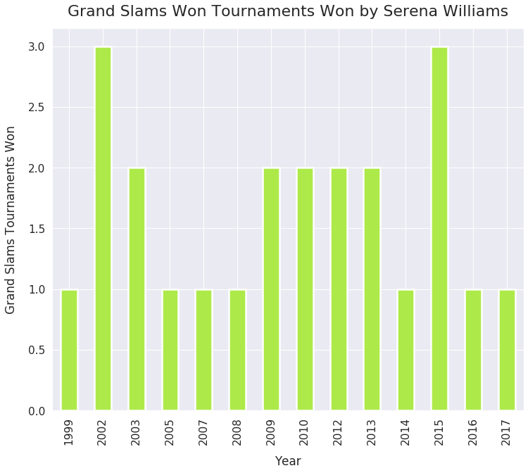

```python
sns.set(font_scale=1.4)
s_result_counts_by_year['win_count'].plot(kind='bar',figsize=(12, 10), linewidth=2.5, color='#ADEA49');
plt.xlabel("Year", labelpad=15)
plt.ylabel("Grand Slams Tournaments Won", labelpad=15)
plt.title("Grand Slams Won Tournaments Won by Serena Williams", y=1.02, fontsize=22);
```

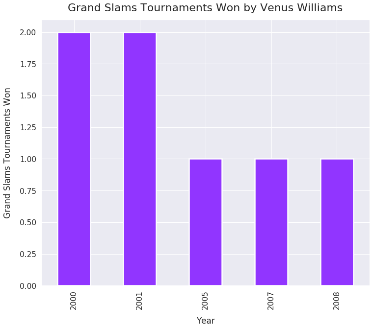

```python
v_result_counts_by_year['win_count'].plot(kind='bar',figsize=(12, 10), linewidth=2.5, color='#9135FF');
plt.xlabel("Year", labelpad=15)
plt.ylabel("Grand Slams Tournaments Won", labelpad=15)
plt.title("Grand Slams Tournaments Won by Venus Williams", y=1.02, fontsize=22);
```

##### Now here is a graph comparing the number of tournaments won by both sisters. Serena is green and Venus is purple. Serena's tournament career lasted longer than Venus's.

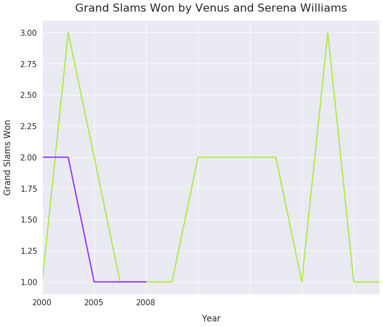

```python
ax = s_result_counts_by_year['win_count'].plot(figsize=(12, 10), linewidth=2.5, color='#ADEA49')
v_result_counts_by_year['win_count'].plot(ax=ax,figsize=(12, 10), linewidth=2.5, color='#9135FF')
plt.xlabel("Year", labelpad=15)
plt.ylabel("Grand Slams Won", labelpad=15)
plt.title("Grand Slams Won by Venus and Serena Williams", y=1.02, fontsize=22);
```

##### Here is another mini dataf rame I created combining the win counts of the two players through the years

```python
s_result_counts_by_year['player'] = 'Serena'
v_result_counts_by_year['player'] = 'Venus'
z = pd.concat([s_result_counts_by_year,v_result_counts_by_year])
r = pd.pivot_table(z, values = ['win_count'], index = ['year','player'], aggfunc = np.sum)
r
```

| year | player | win_count |
| --- | --- | --- |
| 1999 | Serena | 1 |
| 2000 | Venus | 2 |
| 2001 | Venus | 2 |
| 2002 | Serena | 3 |
| 2003 | Serena | 2 |
| 2005 | Serena | 1 |
|  | Venus | 1 |
| 2007 | Serena | 1 |
|  | Venus | 1 |
| 2008 | Serena | 1 |
|  | Venus | 1 |
| 2009 | Serena | 2 |
| 2010 | Serena | 2 |
| 2012 | Serena | 2 |
| 2013 | Serena | 2 |
| 2014 | Serena | 1 |
| 2015 | Serena | 3 |
| 2016 | Serena | 1 |
| 2017 | Serena | 1 |

#### By Tournament

Now I am doing the same thing as in number of wins per year, but for tournament.

```python
s_t_results = serena_wiki[['tournament','result']]
s_t_win_df = s_t_results.loc[s_t_results['result']=='Win']
s_t_win_df['win_count'] = 1
s_result_counts_by_t = pd.pivot_table(s_t_win_df, values = ['win_count'], index = ['tournament'], aggfunc = np.sum)
s_result_counts_by_t
```

| tournament | win_count |
| --- | --- |
| Australian Open | 7 |
| French Open | 3 |
| US Open | 6 |
| Wimbledon Championships | 7 |

```python
v_t_results = venus_wiki[['tournament','result']]
v_t_win_df = v_t_results.loc[v_t_results['result']=='Win']
v_t_win_df['win_count'] = 1
v_result_counts_by_t = pd.pivot_table(v_t_win_df, values = ['win_count'], index = ['tournament'], aggfunc = np.sum)
v_result_counts_by_t
```

| tournament | win_count |
| --- | --- |
| US Open | 2 |
| Wimbledon Championships | 5 |

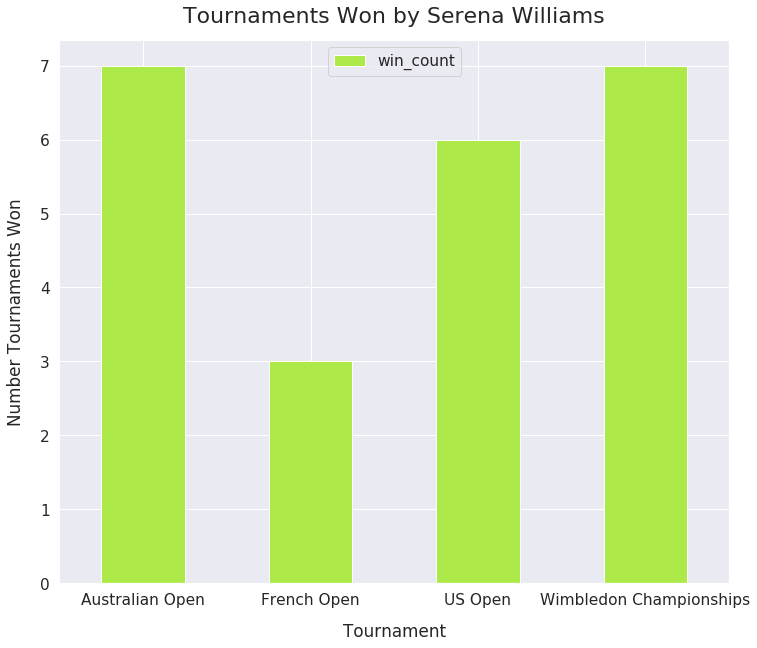

```python
s_bar_chart = s_result_counts_by_t.plot(kind='bar', y='win_count', rot=0, figsize=(12, 10), color='#ADEA49')
plt.xlabel("Tournament", labelpad=15)
plt.ylabel("Number Tournaments Won", labelpad=15)
plt.title("Tournaments Won by Serena Williams", y=1.02, fontsize=22);
s_bar_chart
```

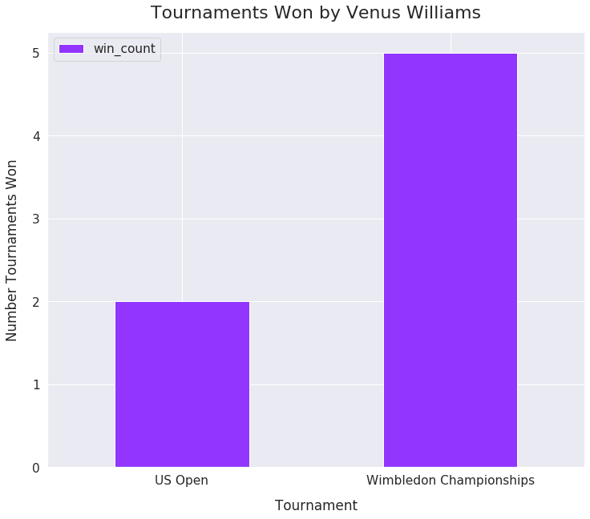

```python
v_bar_chart = v_result_counts_by_t.plot(kind='bar', y='win_count', rot=0, figsize=(12, 10), color='#9135FF')
plt.xlabel("Tournament", labelpad=15)
plt.ylabel("Number Tournaments Won", labelpad=15)
plt.title("Tournaments Won by Venus Williams", y=1.02, fontsize=22);
v_bar_chart
```

###### Both sisters do very well at Wimbledon. Venus has only won the US Open and Wimbledon, and Serena has won each tournament at some point, however never in the same year. Serena's weakest tournament is the French Open.

```python
s_result_counts_by_t['player']='Serena'
v_result_counts_by_t['player']='Venus'
z = pd.concat([s_result_counts_by_t,v_result_counts_by_t])
r = pd.pivot_table(z, values = ['win_count'], index = ['tournament','player'], aggfunc = np.sum)
r
```

| tournament | player | win_count |
| --- | --- | --- |
| Australian Open | Serena | 7 |
| French Open | Serena | 3 |
| US Open | Serena | 6 |
|  | Venus | 2 |
| Wimbledon Championships | Serena | 7 |
|  | Venus | 5 |

# Part 2: Twitter

Next, I thought looking at twitter data through the years from Venus and Serena would be interesting. There are not a lot of tennis players winning at their level while participating in social media. This is what posed a problem when I discovered Venus's twitter data was protected and I could not use it with the API. I decided to use Russian Maria Sharapova's twitter data instead. Although she hasn't won as many Grand Slam Tournaments as Serena or even Venus, she has been Serena's top competitor in many tournaments.

```python
#pip install twitter
#pip install tweepy

import json
import twitter
import tweepy

#Twitter API credentials
consumer_key = "bEObJzz6VCcZjXcXRTp4vY9Mz"
consumer_secret = "iSRyTC2JnQtOa4gWV5SBm3DNjbeY0NySKSHOCy8DZNFZ0vcmoD"
access_key = "1573711369-mmSyRQV8kON83heeW7KebqCAfkJ5a1UGz7P6gCA"
access_secret = "O3KADJDjTwNLS2PtiguJ6f3VIxMYb5mz9aLudVCYsvDvN"
```

```python
def get_all_tweets(screen_name):
    #Twitter only allows access to a users most recent 3240 tweets

    #authorize twitter, initialize tweepy
    auth = tweepy.OAuthHandler(consumer_key, consumer_secret)
    auth.set_access_token(access_key, access_secret)
    api = tweepy.API(auth)

    #initialize a list to hold all the tweepy Tweets
    alltweets = []
    all_tweets = []

    #make initial request for most recent tweets (200 is the maximum allowed count)
    new_tweets = api.user_timeline(screen_name = screen_name,count=200)
    #tweets = [i.AsDict() for i in new_tweets]

    #save most recent tweets
    alltweets.extend(new_tweets)

    #save the id of the oldest tweet less one
    oldest = alltweets[-1].id - 1

    #keep grabbing tweets until there are no tweets left to grab
    while len(new_tweets) > 0:

        #all subsiquent requests use the max_id param to prevent duplicates
        new_tweets = api.user_timeline(screen_name = screen_name,count=200,include_rts=False,max_id=oldest)

        #save most recent tweets
        alltweets.extend(new_tweets)

        #update the id of the oldest tweet less one
        oldest = alltweets[-1].id - 1

        for tweet in alltweets:
            time = tweet.created_at
            retweet = tweet.retweet_count
            favorites = tweet.favorite_count

            twitter_data = {'time':time,'retweet':retweet, 'favorites':favorites}
            all_tweets.append(twitter_data)

    df = pd.DataFrame(all_tweets)
    df['time']=pd.to_datetime(df['time'])
    df = df.set_index('time')

    return(df)
```

### Serena's Twitter Data:

```python
all_serena_tweets = get_all_tweets("serenawilliams")
all_serena_tweets
```

| time | retweet | favorites |
| --- | --- | --- |
| 2019-12-03 18:52:07 | 157 | 0 |
| 2019-12-03 18:47:27 | 92 | 1916 |
| 2019-12-03 15:38:26 | 66 | 336 |
| 2019-11-21 02:58:36 | 388 | 1808 |
| 2019-11-20 19:26:09 | 102 | 421 |
| ... | ... | ... |
| 2013-05-10 17:38:46 | 7 | 11 |
| 2013-05-10 17:37:56 | 12 | 14 |
| 2013-05-10 17:22:54 | 32 | 16 |
| 2013-05-10 17:22:48 | 33 | 20 |
| 2013-05-10 16:24:28 | 73 | 32 |

31259 rows × 2 columns

#### Resample by Month

```python
serena_tweets_by_month=all_serena_tweets.resample('M').sum()
serena_tweets_by_month
```

| time | retweet | favorites |
| --- | --- | --- |
| 2013-05-31 | 14084 | 11382 |
| 2013-06-30 | 26406 | 26778 |
| 2013-07-31 | 3369 | 5028 |
| 2013-08-31 | 15838 | 17232 |
| 2013-09-30 | 33443 | 35175 |
| ... | ... | ... |
| 2019-08-31 | 111537 | 784278 |
| 2019-09-30 | 38845 | 482324 |
| 2019-10-31 | 2567 | 23681 |
| 2019-11-30 | 26333 | 218433 |
| 2019-12-31 | 5355 | 38284 |

80 rows × 2 columns

#### Resample by Year

```python
serena_tweets_by_year=all_serena_tweets.resample('Y').sum()
serena_tweets_by_year
```

| time | retweet | favorites |
| --- | --- | --- |
| 2013-12-31 | 184662 | 222979 |
| 2014-12-31 | 665955 | 1525963 |
| 2015-12-31 | 1872409 | 3979285 |
| 2016-12-31 | 1396913 | 5247600 |
| 2017-12-31 | 3748233 | 21410739 |
| 2018-12-31 | 8608435 | 62610504 |
| 2019-12-31 | 2827848 | 18367123 |

### Doing the same thing with Maria's Data:

```python
maria_tweets_by_year = get_all_tweets("MariaSharapova").resample('Y').sum()
maria_tweets_by_month = get_all_tweets("MariaSharapova").resample('M').sum()
```

## Serena Twitter Visualizations:

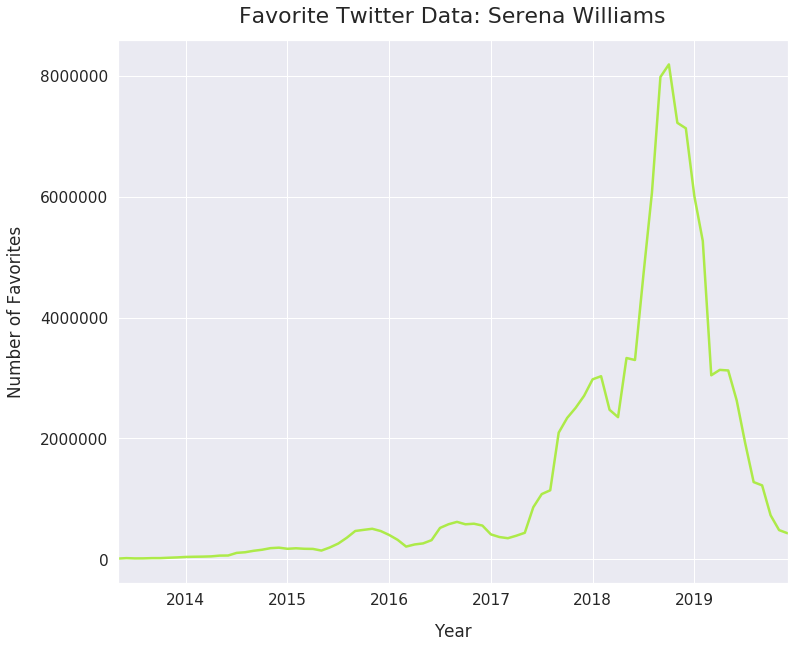

```python
sns.set(font_scale=1.4)
%matplotlib inline
serena_tweets_by_month['favorites'].rolling(6,min_periods=1).apply(np.mean).plot(figsize=(12, 10), linewidth=2.5, color='#ADEA49')
#all_serena_tweets['favorites'].plot(figsize=(12, 10), linewidth=2.5, color='#ADEA49');
plt.xlabel("Year", labelpad=15)
plt.ylabel("Number of Favorites", labelpad=15)
plt.title("Favorite Twitter Data: Serena Williams", y=1.02, fontsize=22);
```

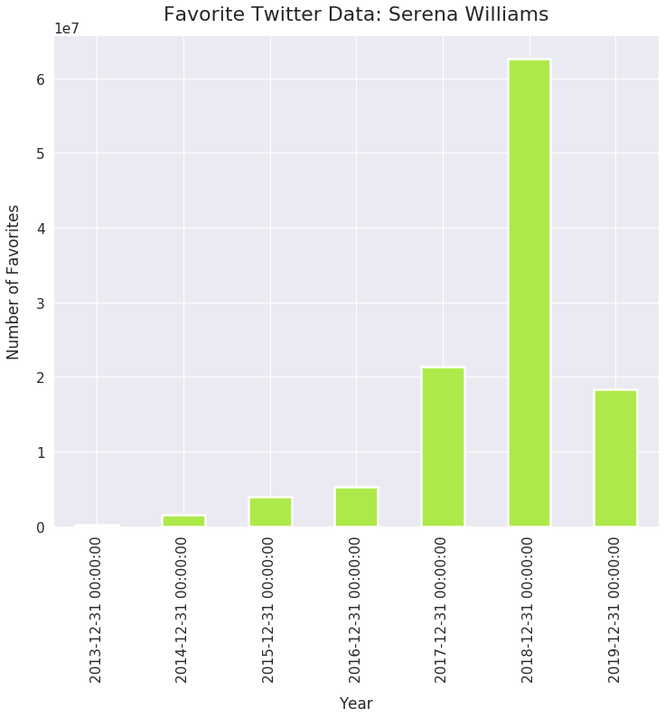

```python
sns.set(font_scale=1.4)
%matplotlib inline
serena_tweets_by_year['favorites'].plot(kind='bar',figsize=(12, 10), linewidth=2.5, color='#ADEA49')
#all_serena_tweets['favorites'].plot(figsize=(12, 10), linewidth=2.5, color='#ADEA49');
plt.xlabel("Year", labelpad=15)
plt.ylabel("Number of Favorites", labelpad=15)
plt.title("Favorite Twitter Data: Serena Williams", y=1.02, fontsize=22);
```

## Maria Twitter Visualizations:

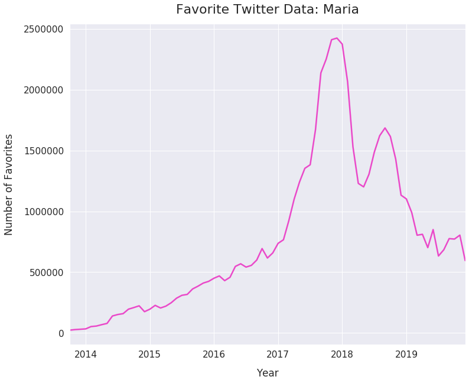

```python
sns.set(font_scale=1.4)
#maria_tweets['favorites'].plot(figsize=(12, 10), linewidth=2.5, color='#EA49C9');
maria_tweets_by_month['favorites'].rolling(6,min_periods=1).apply(np.mean).plot(figsize=(12, 10), linewidth=2.5, color='#EA49C9')
plt.xlabel("Year", labelpad=15)
plt.ylabel("Number of Favorites", labelpad=15)
plt.title("Favorite Twitter Data: Maria", y=1.02, fontsize=22);
```

[figure not shown]

```python
sns.set(font_scale=1.4)
#maria_tweets['favorites'].plot(figsize=(12, 10), linewidth=2.5, color='#EA49C9');
maria_tweets_by_year['favorites'].plot(kind='bar',figsize=(12, 10), linewidth=2.5, color='#EA49C9')
plt.xlabel("Year", labelpad=15)
plt.ylabel("Number of Retweets", labelpad=15)
plt.title("Retweet Twitter Data: Maria", y=1.02, fontsize=22);
```

## Twitter Data: Serena vs Maria

[figure not shown]

```python
ax = serena_tweets_by_year['favorites'].plot(figsize=(12, 10), linewidth=2.5, color='#ADEA49')
maria_tweets_by_year['favorites'].plot(ax=ax,figsize=(12, 10), linewidth=2.5, color='#EA49C9')
plt.xlabel("Year", labelpad=15)
plt.ylabel("Number of Favorites", labelpad=15)
plt.title("Favorite Twitter Data: Serena Williams and Maria", y=1.02, fontsize=22);
```

## Serena Twitter: Retweets vs Favorites

I choose to analyze favorites instead of retweets, so let's bring the number of retweets in and compare it to the number of favorites for Serena's twitter data. The patterns of both are similar, but there are far fewer retweets (blue) than favorites (green).

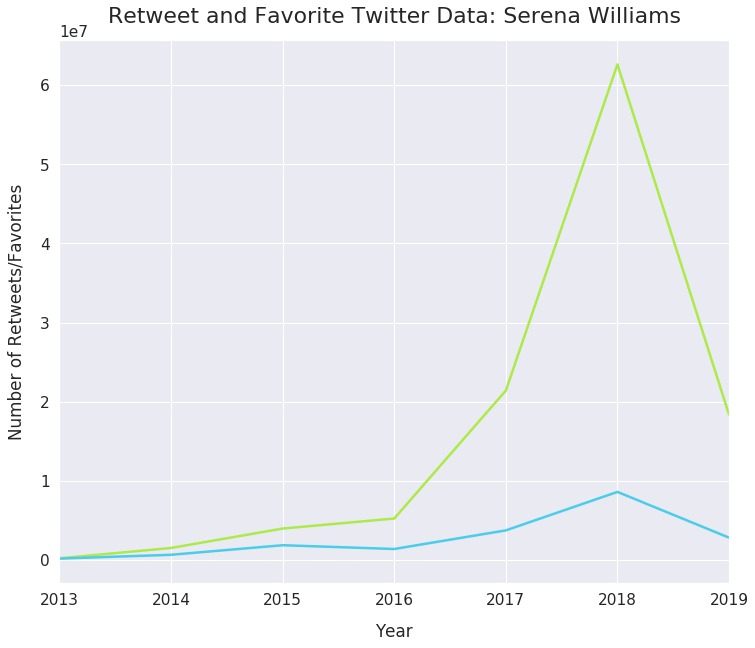

```python
ax = serena_tweets_by_year['favorites'].plot(figsize=(12, 10), linewidth=2.5, color='#ADEA49')
serena_tweets_by_year['retweet'].plot(ax=ax,figsize=(12, 10), linewidth=2.5, color='#49CDEA')
plt.xlabel("Year", labelpad=15)
plt.ylabel("Number of Retweets/Favorites", labelpad=15)
plt.title("Retweet and Favorite Twitter Data: Serena Williams", y=1.02, fontsize=22);
```

# PART 3: Putting it Together (SQL)

I am now going to combine the tennis and twitter data of Serena Williams and Maria Sharapova. I created an ER diagram to illustrate the star-structured database.

[figure not shown]

## Creating the Tables:

```python
#sudo service postgresql start
host="localhost"
dbname="si330"
user="jovyan"
password="si330studentuser"

%load_ext sql
%sql postgres://jovyan:si330studentuser@localhost:5432/si330

import psycopg2
conn = psycopg2.connect(host=host,dbname=dbname, user=user, password=password)
from psycopg2.extras import RealDictCursor
```

```python
%%sql

DROP TABLE IF EXISTS "player";
CREATE TABLE "player" (
  "name" varchar,
  PRIMARY KEY ("name")
);

DROP TABLE IF EXISTS "tennis";
CREATE TABLE "tennis" (
  "name" varchar,
  "year" integer,
  "win_count" varchar,
  "id" integer,
  PRIMARY KEY ("id")
);

CREATE INDEX IF NOT EXISTS "FK" ON  "tennis" ("name");

DROP TABLE IF EXISTS "twitter";
CREATE TABLE "twitter" (
  "name" varchar,
  "year" integer,
  "retweets" integer,
  "favorites" integer,
  "id" integer,
  PRIMARY KEY ("id")
);

CREATE INDEX IF NOT EXISTS "FK" ON  "twitter" ("name");
```

```
 * postgres://jovyan:***@localhost:5432/si330
Done.
Done.
Done.
Done.
Done.
Done.
Done.
Done.
```

```
[]
```

## Generating/Cleaning Data to be added to SQL:

```python
maria_wiki = get_wiki_data('https://en.wikipedia.org/wiki/Maria_Sharapova')
maria_wiki
```

```
  result                                            Data
0    Win  2004 Wimbledon Championships – Women's Singles
1    Win                  2006 US Open – Women's Singles
2   Loss          2007 Australian Open – Women's Singles
3    Win          2008 Australian Open – Women's Singles
4   Loss  2011 Wimbledon Championships – Women's Singles
5   Loss          2012 Australian Open – Women's Singles
6    Win              2012 French Open – Women's Singles
7   Loss                                2013 French Open
8    Win                                2014 French Open
9   Loss          2015 Australian Open – Women's Singles
```

|  | result | year | tournament |
| --- | --- | --- | --- |
| 0 | Win | 2004 | Wimbledon Championships |
| 1 | Win | 2006 | US Open |
| 2 | Loss | 2007 | Australian Open |
| 3 | Win | 2008 | Australian Open |
| 4 | Loss | 2011 | Wimbledon Championships |
| 5 | Loss | 2012 | Australian Open |
| 6 | Win | 2012 | French Open |
| 7 | Loss | 2013 | French Open |
| 8 | Win | 2014 | French Open |
| 9 | Loss | 2015 | Australian Open |

```python
maria_wiki['name'] = 'Maria Sharapova'
maria_wiki
```

|  | result | year | tournament | name |
| --- | --- | --- | --- | --- |
| 0 | Win | 2004 | Wimbledon Championships | Maria Sharapova |
| 1 | Win | 2006 | US Open | Maria Sharapova |
| 2 | Loss | 2007 | Australian Open | Maria Sharapova |
| 3 | Win | 2008 | Australian Open | Maria Sharapova |
| 4 | Loss | 2011 | Wimbledon Championships | Maria Sharapova |
| 5 | Loss | 2012 | Australian Open | Maria Sharapova |
| 6 | Win | 2012 | French Open | Maria Sharapova |
| 7 | Loss | 2013 | French Open | Maria Sharapova |
| 8 | Win | 2014 | French Open | Maria Sharapova |
| 9 | Loss | 2015 | Australian Open | Maria Sharapova |

```python
serena_tweets_by_year['name'] = 'Serena Williams'
serena_tweets_by_year
```

| time | retweet | favorites | name |
| --- | --- | --- | --- |
| 2013-12-31 | 184662 | 222979 | Serena Williams |
| 2014-12-31 | 665955 | 1525963 | Serena Williams |
| 2015-12-31 | 1872409 | 3979285 | Serena Williams |
| 2016-12-31 | 1396913 | 5247600 | Serena Williams |
| 2017-12-31 | 3748233 | 21410739 | Serena Williams |
| 2018-12-31 | 8608435 | 62610504 | Serena Williams |
| 2019-12-31 | 2827848 | 18367123 | Serena Williams |

```python
maria_tweets_by_year['name'] = 'Maria Sharapova'
maria_tweets_by_year
```

| time | retweet | favorites | name |
| --- | --- | --- | --- |
| 2013-12-31 | 55489 | 90154 | Maria Sharapova |
| 2014-12-31 | 1004658 | 1882183 | Maria Sharapova |
| 2015-12-31 | 1352972 | 4257492 | Maria Sharapova |
| 2016-12-31 | 1373407 | 7357677 | Maria Sharapova |
| 2017-12-31 | 2641135 | 22669330 | Maria Sharapova |
| 2018-12-31 | 1236870 | 14625067 | Maria Sharapova |
| 2019-12-31 | 682057 | 8668725 | Maria Sharapova |

```python
s_result_counts_by_year
```

| year | win_count | player |
| --- | --- | --- |
| 1999 | 1 | Serena |
| 2002 | 3 | Serena |
| 2003 | 2 | Serena |
| 2005 | 1 | Serena |
| 2007 | 1 | Serena |
| 2008 | 1 | Serena |
| 2009 | 2 | Serena |
| 2010 | 2 | Serena |
| 2012 | 2 | Serena |
| 2013 | 2 | Serena |
| 2014 | 1 | Serena |
| 2015 | 3 | Serena |
| 2016 | 1 | Serena |
| 2017 | 1 | Serena |

```python
m_result_df = maria_wiki[['result','year']]
m_win_df = m_result_df.loc[m_result_df['result']=='Win']
m_win_df['win_count'] = 1
m_win_df = m_win_df[['year', 'win_count']]
m_result_counts_by_year = pd.pivot_table(m_win_df, values = ['win_count'], index = ['year'], aggfunc = np.sum)
m_result_counts_by_year['name']='Maria Sharapova'
m_result_counts_by_year
```

| year | win_count | name |
| --- | --- | --- |
| 2004 | 1 | Maria Sharapova |
| 2006 | 1 | Maria Sharapova |
| 2008 | 1 | Maria Sharapova |
| 2012 | 1 | Maria Sharapova |
| 2014 | 1 | Maria Sharapova |

## Adding data to SQL:

```python
%%sql
INSERT INTO "player"("name")
VALUES('Serena Williams'),
       ('Maria Sharapova')
ON CONFLICT DO NOTHING
```

```
 * postgres://jovyan:***@localhost:5432/si330
2 rows affected.
```

```
[]
```

```python
%sql select * from player
```

```
 * postgres://jovyan:***@localhost:5432/si330
2 rows affected.
```

| name |
| --- |
| Serena Williams |
| Maria Sharapova |

```python
%%sql
INSERT INTO "tennis"("id","year","win_count","name")
VALUES(0,1999,1,'Serena Williams'),
(1,2002,3,'Serena Williams'),
(2,2003,2,'Serena Williams'),
(3,2005,1,'Serena Williams'),
(4,2007,1,'Serena Williams'),
(5,2008,1,'Serena Williams'),
(6,2009,2,'Serena Williams'),
(7,2010,2,'Serena Williams'),
(8,2012,2,'Serena Williams'),
(9,2013,2,'Serena Williams'),
(10,2014,1,'Serena Williams'),
(11,2015,3,'Serena Williams'),
(12,2016,1,'Serena Williams'),
(13,2017,1,'Serena Williams'),
(14,2004,1,'Maria Sharapova'),
(15,2006,1,'Maria Sharapova'),
(16,2008,1,'Maria Sharapova'),
(17,2012,1,'Maria Sharapova'),
(18,2014,1,'Maria Sharapova')
ON CONFLICT DO NOTHING
```

```
 * postgres://jovyan:***@localhost:5432/si330
19 rows affected.
```

```
[]
```

```python
%sql select * from tennis
```

```
 * postgres://jovyan:***@localhost:5432/si330
19 rows affected.
```

| name | year | win_count | id |
| --- | --- | --- | --- |
| Serena Williams | 1999 | 1 | 0 |
| Serena Williams | 2002 | 3 | 1 |
| Serena Williams | 2003 | 2 | 2 |
| Serena Williams | 2005 | 1 | 3 |
| Serena Williams | 2007 | 1 | 4 |
| Serena Williams | 2008 | 1 | 5 |
| Serena Williams | 2009 | 2 | 6 |
| Serena Williams | 2010 | 2 | 7 |
| Serena Williams | 2012 | 2 | 8 |
| Serena Williams | 2013 | 2 | 9 |
| Serena Williams | 2014 | 1 | 10 |
| Serena Williams | 2015 | 3 | 11 |
| Serena Williams | 2016 | 1 | 12 |
| Serena Williams | 2017 | 1 | 13 |
| Maria Sharapova | 2004 | 1 | 14 |
| Maria Sharapova | 2006 | 1 | 15 |
| Maria Sharapova | 2008 | 1 | 16 |
| Maria Sharapova | 2012 | 1 | 17 |
| Maria Sharapova | 2014 | 1 | 18 |

```python
%%sql
INSERT INTO "twitter"("id","year","retweets","favorites","name")
VALUES(0,2013,185086,223228,'Serena Williams'),
(1,2014,666223,1526721,'Serena Williams'),
(2,2015,1875080,3984212,'Serena Williams'),
(3,2016,1397733,5247669,'Serena Williams'),
(4,2017,3750362,21415809,'Serena Williams'),
(5,2018,8614279,62622172,'Serena Williams'),
(6,2019,2829361,18369078,'Serena Williams'),
(7,2013,55491,90203,'Maria Sharapova'),
(8,2014,1004697,1881803,'Maria Sharapova'),
(9,2015,1353230,4255774,'Maria Sharapova'),
(10,2016,1373375,7354000,'Maria Sharapova'),
(11,2017,2641314,22669467,'Maria Sharapova'),
(12,2018,1237108,14628479,'Maria Sharapova'),
(13,2019,681598,8667926,'Maria Sharapova')
ON CONFLICT DO NOTHING
```

```
 * postgres://jovyan:***@localhost:5432/si330
14 rows affected.
```

```
[]
```

```python
%sql select * from twitter
```

```
 * postgres://jovyan:***@localhost:5432/si330
14 rows affected.
```

| name | year | retweets | favorites | id |
| --- | --- | --- | --- | --- |
| Serena Williams | 2013 | 185086 | 223228 | 0 |
| Serena Williams | 2014 | 666223 | 1526721 | 1 |
| Serena Williams | 2015 | 1875080 | 3984212 | 2 |
| Serena Williams | 2016 | 1397733 | 5247669 | 3 |
| Serena Williams | 2017 | 3750362 | 21415809 | 4 |
| Serena Williams | 2018 | 8614279 | 62622172 | 5 |
| Serena Williams | 2019 | 2829361 | 18369078 | 6 |
| Maria Sharapova | 2013 | 55491 | 90203 | 7 |
| Maria Sharapova | 2014 | 1004697 | 1881803 | 8 |
| Maria Sharapova | 2015 | 1353230 | 4255774 | 9 |
| Maria Sharapova | 2016 | 1373375 | 7354000 | 10 |
| Maria Sharapova | 2017 | 2641314 | 22669467 | 11 |
| Maria Sharapova | 2018 | 1237108 | 14628479 | 12 |
| Maria Sharapova | 2019 | 681598 | 8667926 | 13 |

#### Now the data is stored and the same structure can be used for other players with both tennis and twitter data

```python
%%sql
select from "tennis" t1 join "twitter" t2 on t1.name=t2.name
```

```
 * postgres://jovyan:***@localhost:5432/si330
133 rows affected.
```

## Is there a correlation between number of wins and number of favorites on Twitter?

I will be using Serena's data for this. First I need to get data frames of the same length, so that would be from years 2013 to 2017, because those are the years included in the same data frame.

```python
twt = serena_tweets_by_year.iloc[:5]
```

```python
tns = s_result_counts_by_year.iloc[9:]
```

```python
import scipy.stats as stats
import numpy as np
corr, pval=stats.pearsonr(twt['favorites'], tns['win_count'])
corr, pval
```

```
(-0.3665468807583814, 0.5439702074671187)
```

##### Negative correlation, insignificant pval, thus there is NO significant evidence that the number of wins and number of favorites on twitter per year is correlated.